# Predykcja umieralności na nowotwór Glioblastoma

Wioleta Stojak i Ewelina Karbowiak

23 października 2016

**Abstract** Celem projektu jest zbudowanie algorytmu, który na podstawie danych o pacjentach ze zdiagnozowanym nowotworem Glioblastoma będzie mógł możliwie dokładnie oszacować czy pacjent przeżyje 1 rok od diagnozy. Faza pierwsza dotyczy identyfikacji czynników, które różnicują prognozy pacjentów w zależności od tła genetycznego.

## Dane

Dostępne dane zawierały informacje o pacjentach w zależności od wieku, podtypu nowotworu, stanu pacjenta po pierwszym roku od diagnozy oraz wartości ekspresji 16115 genów.

```r
#wczytanie zbióru danych
load("C:/Users/Wioleta/Downloads/GlioblastomaWide.rda")
#fragment zbioru danych
GlioblastomaWide[1:5,1:7]
```

```
##          sampleID Cluster age death1y X..100133144 X..100134869 X..10357
## 1 TCGA.02.0047.01 C10-GBM  78   alive    -1.686874       -0.573   -0.986
## 2 TCGA.02.0055.01 C10-GBM  62    dead           NA        0.642   -1.788
## 3 TCGA.02.2483.01 C10-GBM  43   alive    -1.747874        0.471   -0.845
## 4 TCGA.02.2485.01 C10-GBM  53   alive     0.693126        0.573   -0.239
## 5 TCGA.02.2486.01 C10-GBM  64   alive    -0.831874       -1.065   -0.793
```

## Indentyfikacja istotnych genów

Do uzyskania informacji o genach i ich istotności posłużyłyśmy się testem t studenta oraz zastosowałyśmy **metodę fdr** do estymacji otrzymanych p-wartości. Na początek pacjenci zostali podzieleni na dwie grupy. W pierwszej znaleźli się ci, którzy przeżyli pierwszy rok od postawionej diagnozy, natomiast do drugiej grupy zostali przydzieleni pozostali uczestnicy badania, którzy nie przeżyli pierwszego roku od diagnozy. Ostatecznie wybrałyśmy 45 istotnych genów analizując **volcano plot**, który powstał w oparciu o estymacje p-wartości z testu **t.test** oraz o różnice średnich ekspresji genów w wyżej wymienionych grupach.

## Kod

> Potrzebne pakiety

```r
library(ggplot2)
library(reshape2)
```

> Podział pacjentów oraz odrzucenie genów z małą liczbą obserwacji

```r
dane<-GlioblastomaWide
dead<-dane[dane$death1y == "dead",]
alive<-dane[dane$death1y == "alive",]
#odrzucamy kolumny z zbyt dużą iloscią NA (odrzucenie w granicy 1.5%)
n2<-nrow(dead)*4/6
n3<-nrow(alive)*4/6
j<-c(1:16115)
j<-colnames(dane[,-c(1:4)])

for (i in j){
  if(length(which(is.na(dead[i])))>n2 | length(which(is.na(alive[i])))>n3){
    dane[,i]<-NULL
  }
}
```

> Histogram ekspresji genów

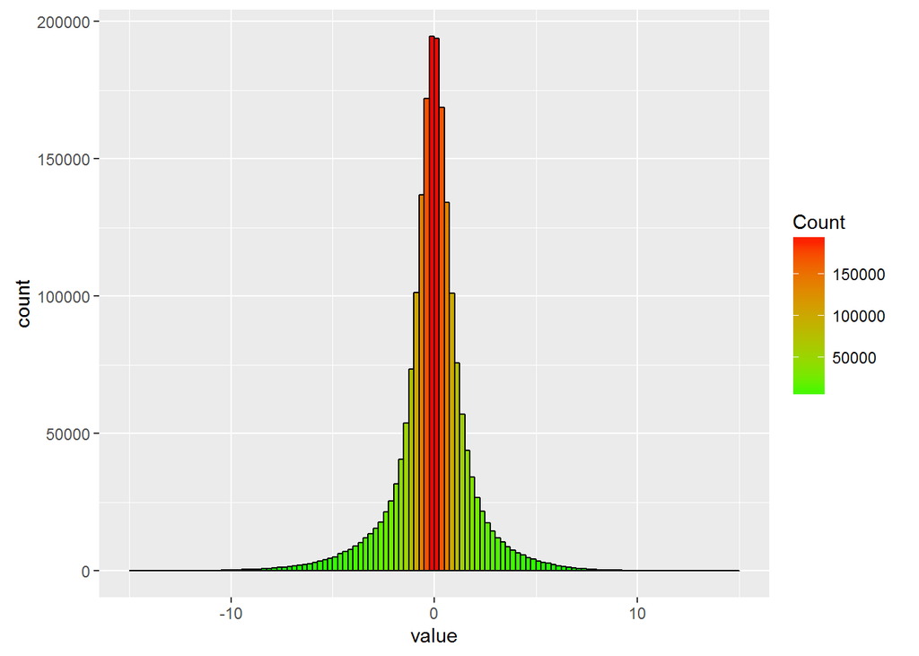

```r
#wykonujemy histogram aby przyjrzeć się rozkładowi ekspresji genów
dane2<-as.matrix.data.frame(dane[,-c(1:4)])
dane3<-melt(dane2)
g <- ggplot(dane3,aes(x=value))
g <- g + geom_histogram(aes(fill=..count..),col="black",breaks=seq(-15,15,0.25))+
  scale_fill_gradient("Count", low = "green", high = "red")
g
```

> Wykonujemy test t-studenta dla poszczególnych kolumn w wydzielonych grupach

```r
#liczymy wartość p-value dla testu t-studenta
dead2<-dane2[dane$death1y == "dead",]
alive2<-dane2[dane$death1y == "alive",]
pvalue<-NULL
for (i in 1:ncol(dane2)){
  x<-dead2[,i]
  y<-alive2[,i]
  t<-t.test(x,y)
  pvalue[i]<-t$p.value
}
#korzystamy z metody "fdr" aby poprawić p-wartości
pvalue_poprawka<-p.adjust(pvalue, method = "fdr")
rpvalue_poprawka<-as.data.frame(pvalue_poprawka)
rpvalue<-as.data.frame(pvalue)
```

> Poniżej znajdują się histogramy p-wartości i p-wartości estymowanych **metodą “fdr”**

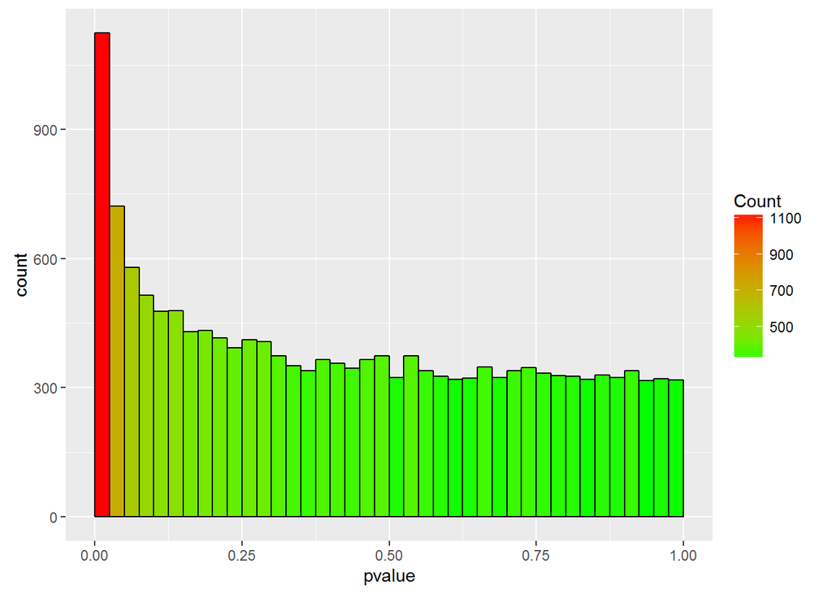

```r
ggplot(data=rpvalue, aes(pvalue)) + geom_histogram(aes(fill=..count..),col="black",breaks=seq(0,1,0.025))+ scale_fill_gradient("Count", low = "green", high = "red")
```

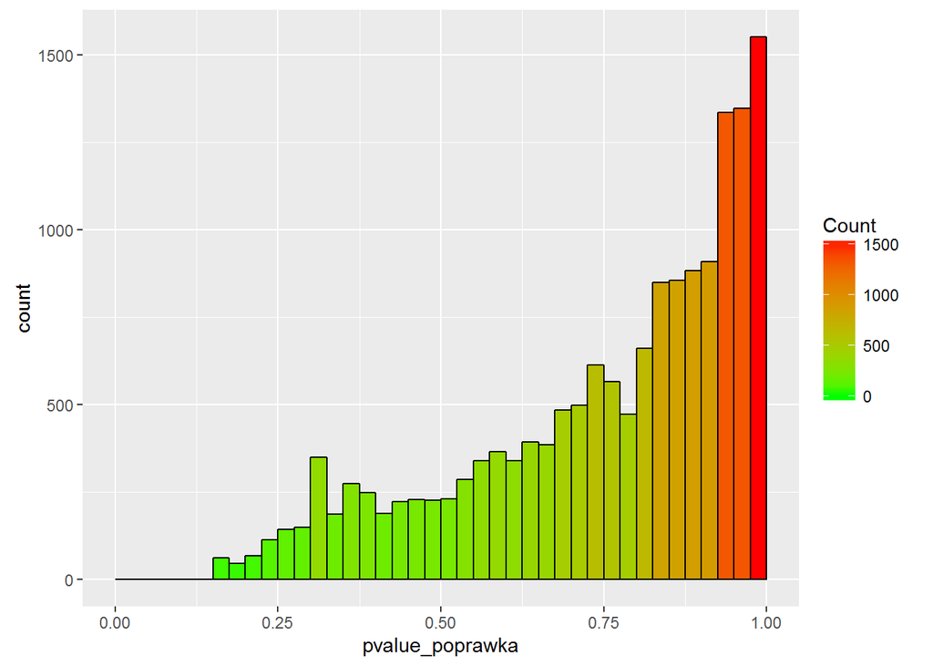

```r
ggplot(data=rpvalue_poprawka, aes(pvalue_poprawka)) + geom_histogram(aes(fill=..count..),col="black",breaks=seq(0,1,0.025))+ scale_fill_gradient("Count", low = "green", high = "red")
```

> Typowanie genów różnicujących - **Volcano plot**

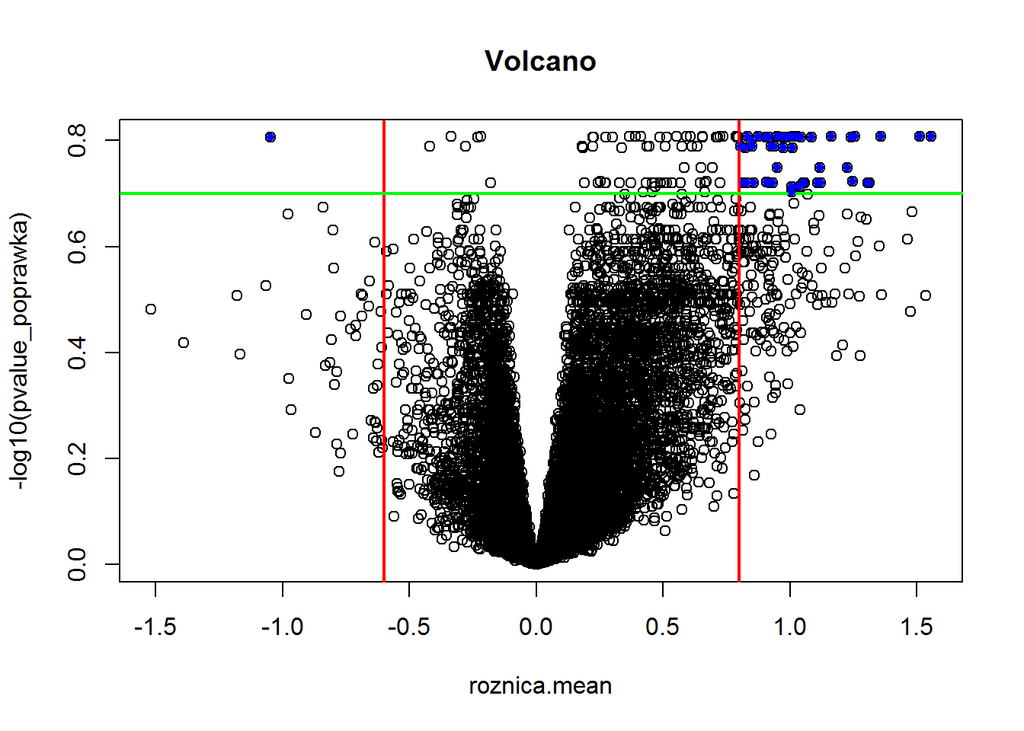

```r
#Dzielimy pacjentów na dwie grupy i wyliczamy róznice miedzy średnimi aby wyróznic geny o istotnym rozrzucie

dead2.mean<-apply(dead2,2,function(x)mean(x,na.rm=TRUE))
alive2.mean<-apply(alive2,2,function(x)mean(x,na.rm=TRUE))
roznica.mean <- (dead2.mean-alive2.mean)

#korzystamy z volcano plot aby przedstawić obszar rozrzutu

plot(roznica.mean, -log10(pvalue_poprawka),main = "Volcano")
roz.meanodc = 0.8
roz.meanodc1 = -0.6
pvalue.odc = 1/10^(0.7)
abline(v = roz.meanodc, col = "red", lwd = 2)
abline(v = roz.meanodc1, col = "red", lwd = 2)
abline(h = -log10(pvalue.odc), col = "green", lwd = 2)
filtr1<-roznica.mean>=roz.meanodc
filtr2<-roznica.mean<=roz.meanodc1
filtr3<-pvalue_poprawka <= pvalue.odc
#zaznaczamy na wykresie punkty spełniające podane warunki
points (roznica.mean[filtr3 & filtr2],
    -log10(pvalue_poprawka[filtr3 & filtr2]),
    pch = 20, col = "blue")
points (roznica.mean[filtr3 & filtr1],
    -log10(pvalue_poprawka[filtr3 & filtr1]),
    pch = 20, col = "blue")
```

```r
#ustalenie warunków, które powinny spełniać geny istotne
warunki=(filtr1|filtr2)&filtr3
istotne<-dane2[,warunki]
```

> Liczba istotnych genów

```r
koncowy<-as.data.frame(istotne)
dim(istotne)
```

```
## [1] 125  45
```

> Tworzymy podzbiór uczący się i testowy

```r
rozmiardanych <- floor(0.75 * nrow(dane))
## aby probki były za kazdym razem te same
set.seed(123)
train.podz <- sample(seq_len(nrow(istotne)), size = rozmiardanych)

train <- istotne[train.podz, ]
test <- istotne[-train.podz, ]
```